# Tutorial 1 - What is circular data?

## Introduction

Most researchers will be familiar with the concept of measurement levels of variables. The most popular two being continuous data and categorical data. Circular data is another type of measurement with properties that distinguish it from other data types. The main property of circular data is the fact that it is periodical. What this means is that there is no true start or end point, but rather a continuous scale that loops back on itself.

An example would be the time of day as represented on the clock. As time passes the hands on the face of a clock will inevitably be bound to pass the same 24 hours over and over. This also means that distances can not be interpreted as linear. The difference in time between 1 o’clock and 3 o’clock is the same as the distance between 23 o’clock and 1 o’clock, that is, two hours. Another quality of circular data is that every value can be seen to have an opposite value. A second instrument that provides circular measurements is the compass. When we look at directions on a compass, we would say that north is the opposite of south, and east is the opposite of west. Circumplex models also use this quality to create a continuum of related values, where opposite values are 180 degrees apart. Examples of this from social and behavioural science are Schwartz’ theory of basic values, Russel’s mood scale and Leary’s interpersonal circumplex.

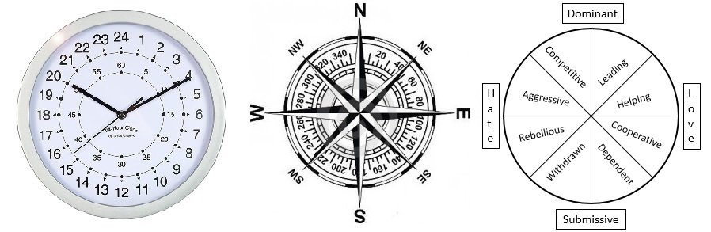

*The clock, compass and Leary’s (1957) interpersonal circumplex. All examples of instruments providing circular data.*

## Example

Circular data has applications for many disciplines, including the social and behavioural sciences. For example, measuring directions can be used to track eye movement or body movement during an experiment. In a study by Warren et al. (2017), 39 participants were asked to navigate a Euclidian and a non-Euclidian maze using a virtual reality headset. The Euclidian and non-Euclidian mazes were identical except for the presense of two ‘wormholes’ that would transport participants instantly. The movement of participants through these mazes was tracked for eight trials. The mazes were designed in a way that the scores would be higher if participants opted to use wormholes present in the non-Euclidian maze.

The researchers used this data to test whether participants were capable of learning to navigate a space using wormholes, which may indicate whether human knowledge on navigation space is Euclidian or not.

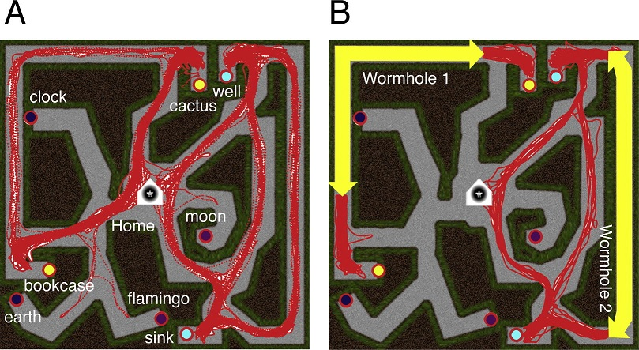

*The virtual mazes A (Euclidian) and B (non-Euclidian) used in the study by Warren et al. (2017).*

## Circular data

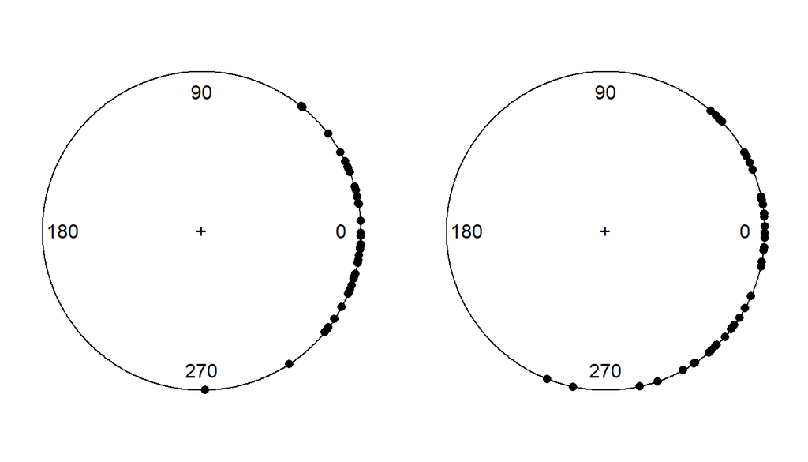

*The dataset for the Euclidian maze (left) and non-Euclidian maze (right) plotted on the circle.*

Values in degrees are easily converted to radians and vice versa. The formulae for this are

$degrees*( \pi /180) = radians$

$radians* (180/ \pi) = degrees$

## Conclusion

Depending on the type of data we want to analyze, we use different methods. For example, if we want to predict a categorical outcome a binomial or multinomial logistic regression is prefered to using a normal linear regression. In the same vein, circular data should be analyzed using methods tailored to the unique attributes of such data. The next tutorial will present how to obtain and interpret desciptive statistics for circular data.

## References

Leary, T. (1957). *Interpersonal diagnosis of personality: A functional theory and methodology for personality evaluation.* New York: Ronald Press.

Warren, W. H., Rothman, D. B., Schnapp, B. H., & Ericson, J. D. (2017). Wormholes in virtual space: From cognitive maps to cognitive graphs. *Cognition, 166*, 152-163.